# Exact Divide and Conquer Inference in Bayesian Multivariate Linear Regression

Sudipto Banerjee

*Note:* To generate this HTML file, run `renderExactMvLM.sh` in the terminal from the `src/bigDataRegression/mniw/exactMvLM/run` directory. Alternatively find the source `Rmd` and `R` files in that same folder starting from the `BGC_2023` GitHub home.

```bash
# Navigate to the directory and run the compilation script
cd src/bigDataRegression/mniw/exactMvLM/run
./renderExactMvLM.sh
```

# 1 Conjugate Bayesian Multivariate Linear Regression

A conjugate Bayesian multivariate linear model (the MNIW model) is given by:

$$Y \mid \beta, \Sigma, X \sim
MN_{n,q}(X\beta, I_n, \Sigma)$$
$$\beta \mid \Sigma \sim MN_{p,q}(M_0 m_0, M_0,
\Sigma)$$
$$\Sigma \sim IW(\nu_0,
\Psi_0)$$

Unknown parameters include the regression coefficient matrix and the covariance matrix, i.e., $\theta = \{\beta, \Sigma\}$.

The likelihood of the data is:

$$p(Y \mid \beta, \Sigma) \propto
|\Sigma|^{-n/2} \exp\left\{ -\frac{1}{2} \text{tr}\left[ \Sigma^{-1} (Y
- X\beta)^{\top} (Y - X\beta) \right] \right\}$$

The joint posterior density is $p(\beta, \Sigma \mid Y) \propto p(\Sigma) \times p(\beta \mid \Sigma) \times p(Y \mid \beta, \Sigma)$.

# 2 Deriving the Joint Posterior $p(\beta, \Sigma \mid Y)$

$$\begin{aligned}
p(\beta, \Sigma \mid Y) &\propto IW(\Sigma \mid \nu_0, \Psi_0)
\times MN(\beta \mid M_0 m_0, M_0, \Sigma) \times MN(Y \mid X\beta, I_n,
\Sigma) \\
&\propto |\Sigma|^{-\frac{\nu_0 + q + 1}{2}} \exp\left\{
-\frac{1}{2} \text{tr}\left( \Sigma^{-1} \Psi_0 \right) \right\} \\
&\quad \times |\Sigma|^{-\frac{p}{2}} \exp\left\{ -\frac{1}{2}
\text{tr}\left[ \Sigma^{-1} (\beta - M_0 m_0)^{\top} M_0^{-1} (\beta -
M_0 m_0) \right] \right\} \\
&\quad \times |\Sigma|^{-\frac{n}{2}} \exp\left\{ -\frac{1}{2}
\text{tr}\left[ \Sigma^{-1} (Y - X\beta)^{\top} (Y - X\beta) \right]
\right\} \\
&\propto |\Sigma|^{-\frac{\nu_0 + n + p + q + 1}{2}} \exp\left\{
-\frac{1}{2} \text{tr}\left( \Sigma^{-1} \left[ \Psi_0 + Q(\beta, Y)
\right] \right) \right\}
\end{aligned}$$

where the quadratic terms in $\beta$ are combined as:

$$Q(\beta, Y) = (\beta - M_0 m_0)^{\top}
M_0^{-1} (\beta - M_0 m_0) + (Y - X\beta)^{\top} (Y -
X\beta)$$

# 3 Matrix Completion of Square

Expanding and recombining $Q(\beta, Y)$ (noting that $M_0$ is symmetric, so $(M_0 m_0)^\top M_0^{-1} \beta = m_0^\top M_0 M_0^{-1} \beta = m_0^\top \beta$):

$$\begin{aligned}
Q(\beta, Y) &= (\beta - M_0 m_0)^{\top} M_0^{-1} (\beta - M_0 m_0) +
(Y - X\beta)^{\top} (Y - X\beta) \\
&= \beta^{\top} M_0^{-1} \beta - \beta^{\top} m_0 - m_0^{\top} \beta
+ m_0^{\top} M_0 m_0 + Y^{\top} Y - Y^{\top} X \beta - \beta^{\top}
X^{\top} Y + \beta^{\top} X^{\top} X \beta \\
&= \beta^{\top} (M_0^{-1} + X^{\top} X) \beta - \beta^{\top} (m_0 +
X^{\top} Y) - (m_0^{\top} + Y^{\top} X) \beta + (m_0^{\top} M_0 m_0 +
Y^{\top} Y) \\
&= (\beta - Mm)^{\top} M^{-1} (\beta - Mm) + S^\ast
\end{aligned}$$

where the updated parameters $M$, $m$, and $S^\ast$ are defined as:

$$M^{-1} = M_0^{-1} + X^{\top} X, \quad m
= m_0 + X^{\top} Y, \quad S^\ast = m_0^{\top} M_0 m_0 + Y^{\top} Y -
m^{\top} M m$$

# 4 Factorizing the Joint Posterior

Substituting the completed square back into the joint posterior yields:

$$p(\beta, \Sigma \mid Y) \propto \left(
|\Sigma|^{-\frac{\nu + q + 1}{2}} \exp\left\{ -\frac{1}{2}
\text{tr}\left[ \Sigma^{-1} \Psi \right] \right\} \right) \times \left(
|\Sigma|^{-\frac{p}{2}} \exp\left\{ -\frac{1}{2} \text{tr}\left[
\Sigma^{-1} (\beta - Mm)^{\top} M^{-1} (\beta - Mm) \right] \right\}
\right)$$

where:

$$\nu = \nu_0 + n, \quad \Psi = \Psi_0 +
S^\ast = \Psi_0 + m_0^{\top} M_0 m_0 + Y^{\top} Y - m^{\top} M
m$$

This factorizes into $IW(\Sigma \mid \nu, \Psi) \times MN(\beta \mid Mm, M, \Sigma)$.

# 5 Bayesian Regression using Divide & Conquer

Partition data into blocks $\{Y_t, X_t\}$ for $t = 1, 2, \ldots, T$. For sequential block $t$, updating from $t-1$ follows:

$$m_t = m_{t-1} + X_t^{\top} Y_t, \quad
M_t^{-1} = M_{t-1}^{-1} + X_t^{\top} X_t, \quad \nu_t = \nu_{t-1} +
n_t$$
$$Q_t = Y_t^{\top} Y_t +
m_{t-1}^{\top} M_{t-1} m_{t-1} - m_t^{\top} M_t m_t, \quad \Psi_t =
\Psi_{t-1} + Q_t$$

Summing $Q_t$ over $t=1,\ldots,T$ collapses telescopically:

$$\sum_{t=1}^T Q_t = Y^\top Y + m_0^\top
M_0 m_0 - m_{\text{full}}^\top M_{\text{full}}
m_{\text{full}}$$

This establishes that streaming updates over blocks **EXACTLY** match full-data posterior parameters.

# 6 Empirical Analysis: Custom R Sampler (`mniwSamplerDivideAndConquer`)

Loading the dataset files directly from `../data/X.txt` and `../data/Y.txt`, processing them sequentially via `mniwSamplerDivideAndConquer`, and comparing streaming results against full-data batch updates.

```r
# Ingest raw dataset files
X_raw  <- as.matrix(read.table("../data/X.txt"))
Y_raw  <- as.matrix(read.table("../data/Y.txt"))
X_full <- cbind(1, X_raw)
Y_full <- Y_raw

p_dim <- ncol(X_full)
q_dim <- ncol(Y_full)

# Prior parameter setup
m0     <- matrix(0, nrow = p_dim, ncol = q_dim)
M0_inv <- diag(1, p_dim)
nu0    <- q_dim + 2
Psi0   <- diag(1, q_dim)

# Partition data into T = 5 sequential blocks
T_blocks    <- 5
block_sizes <- split(seq_len(nrow(X_full)), cut(seq_len(nrow(X_full)), T_blocks, labels = FALSE))
data_blocks <- lapply(block_sizes, function(idx) {
  list(X = X_full[idx, ], Y = Y_full[idx, ])
})

# 1. Sequential Divide & Conquer Sampler (Custom R)
set.seed(42)
res_dc <- mniwSamplerDivideAndConquer(data_blocks, m0, M0_inv, nu0, Psi0, n_samples = 2000)

# 2. Full Data Batch Sampler
full_data_block <- list(list(X = X_full, Y = Y_full))
set.seed(42)
res_batch <- mniwSamplerDivideAndConquer(full_data_block, m0, M0_inv, nu0, Psi0, n_samples = 2000)
```

## 6.1 Parameter Precision Comparison (Custom Sampler)

```r
diff_m     <- max(abs(res_dc$post_params$m - res_batch$post_params$m))
diff_M_inv <- max(abs(res_dc$post_params$M_inv - res_batch$post_params$M_inv))
diff_Psi   <- max(abs(res_dc$post_params$Psi - res_batch$post_params$Psi))
diff_nu    <- abs(res_dc$post_params$nu - res_batch$post_params$nu)

param_comp <- data.frame(
  Parameter_Matrix = c("Location Vector (m)", "Precision Matrix (M^{-1})", "Scale Matrix (Psi)", "Degrees of Freedom (nu)"),
  Max_Absolute_Difference = c(diff_m, diff_M_inv, diff_Psi, diff_nu)
)

kable(param_comp, digits = 16, caption = "Numerical Equivalence of Posterior Parameters (Custom Sampler)")
```

Numerical Equivalence of Posterior Parameters (Custom Sampler)

| Parameter_Matrix | Max_Absolute_Difference |
| --- | --- |
| Location Vector (m) | 1.81900e-12 |
| Precision Matrix (M^{-1}) | 9.09500e-13 |
| Scale Matrix (Psi) | 1.81899e-11 |
| Degrees of Freedom (nu) | 0.00000e+00 |

## 6.2 Posterior Parameter Summaries (Custom Sampler)

### 6.2.1 Regression Coefficients (Beta) Summary (Custom Sampler)

| Param | Mean | SD | 2.5% | 97.5% |
| --- | --- | --- | --- | --- |
| Beta[1,1] | 0.0251 | 0.0283 | -0.0310 | 0.0823 |
| Beta[2,1] | 1.0064 | 0.0286 | 0.9528 | 1.0629 |
| Beta[3,1] | 4.0103 | 0.0203 | 3.9700 | 4.0499 |
| Beta[4,1] | 0.4912 | 0.0166 | 0.4593 | 0.5241 |
| Beta[1,2] | 0.0011 | 0.0352 | -0.0671 | 0.0695 |
| Beta[2,2] | 3.0043 | 0.0367 | 2.9349 | 3.0779 |
| Beta[3,2] | 1.4867 | 0.0259 | 1.4371 | 1.5389 |
| Beta[4,2] | 0.9967 | 0.0208 | 0.9557 | 1.0388 |
| Beta[1,3] | -0.0452 | 0.0495 | -0.1425 | 0.0499 |
| Beta[2,3] | 1.9940 | 0.0510 | 1.8921 | 2.0968 |
| Beta[3,3] | -1.0334 | 0.0368 | -1.1077 | -0.9634 |
| Beta[4,3] | 5.0056 | 0.0291 | 4.9484 | 5.0596 |

### 6.2.2 Covariance Matrix (Sigma) Summary (Custom Sampler)

| Param | Mean | SD | 2.5% | 97.5% |
| --- | --- | --- | --- | --- |
| Sigma[1,1] | 0.9546 | 0.0385 | 0.8820 | 1.0309 |
| Sigma[2,1] | 0.4951 | 0.0199 | 0.4575 | 0.5347 |
| Sigma[3,1] | -0.9386 | 0.0378 | -1.0136 | -0.8673 |
| Sigma[1,2] | 0.4951 | 0.0199 | 0.4575 | 0.5347 |
| Sigma[2,2] | 1.4894 | 0.0515 | 1.3949 | 1.5965 |
| Sigma[3,2] | 1.0074 | 0.0641 | 0.8882 | 1.1392 |
| Sigma[1,3] | -0.9386 | 0.0378 | -1.0136 | -0.8673 |
| Sigma[2,3] | 1.0074 | 0.0641 | 0.8882 | 1.1392 |
| Sigma[3,3] | 2.9668 | 0.0836 | 2.8113 | 3.1354 |

## 6.3 Quantile-Quantile (QQ) Validation (Custom Sampler)

### 6.3.1 Regression Coefficients ($\beta$) QQ-Plots

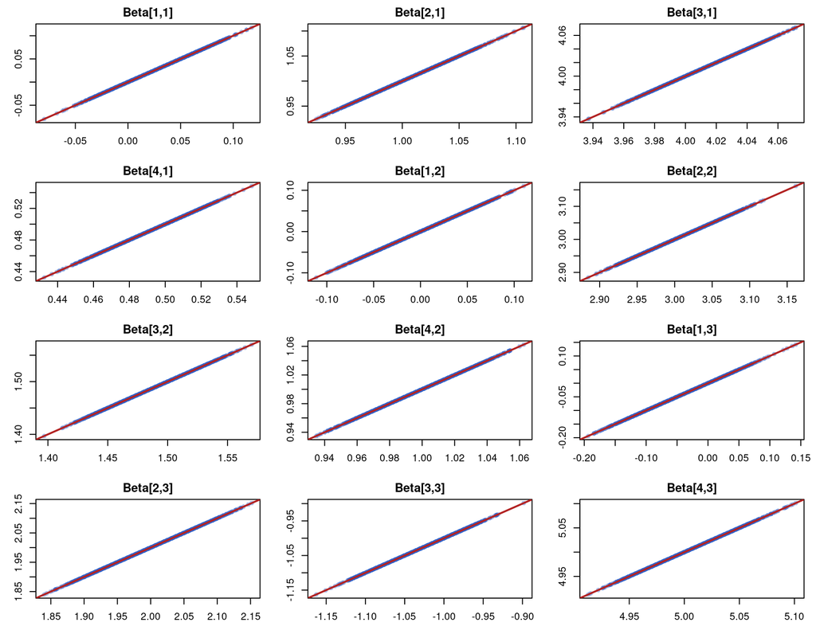

### 6.3.2 Covariance Matrix ($\Sigma$) QQ-Plots

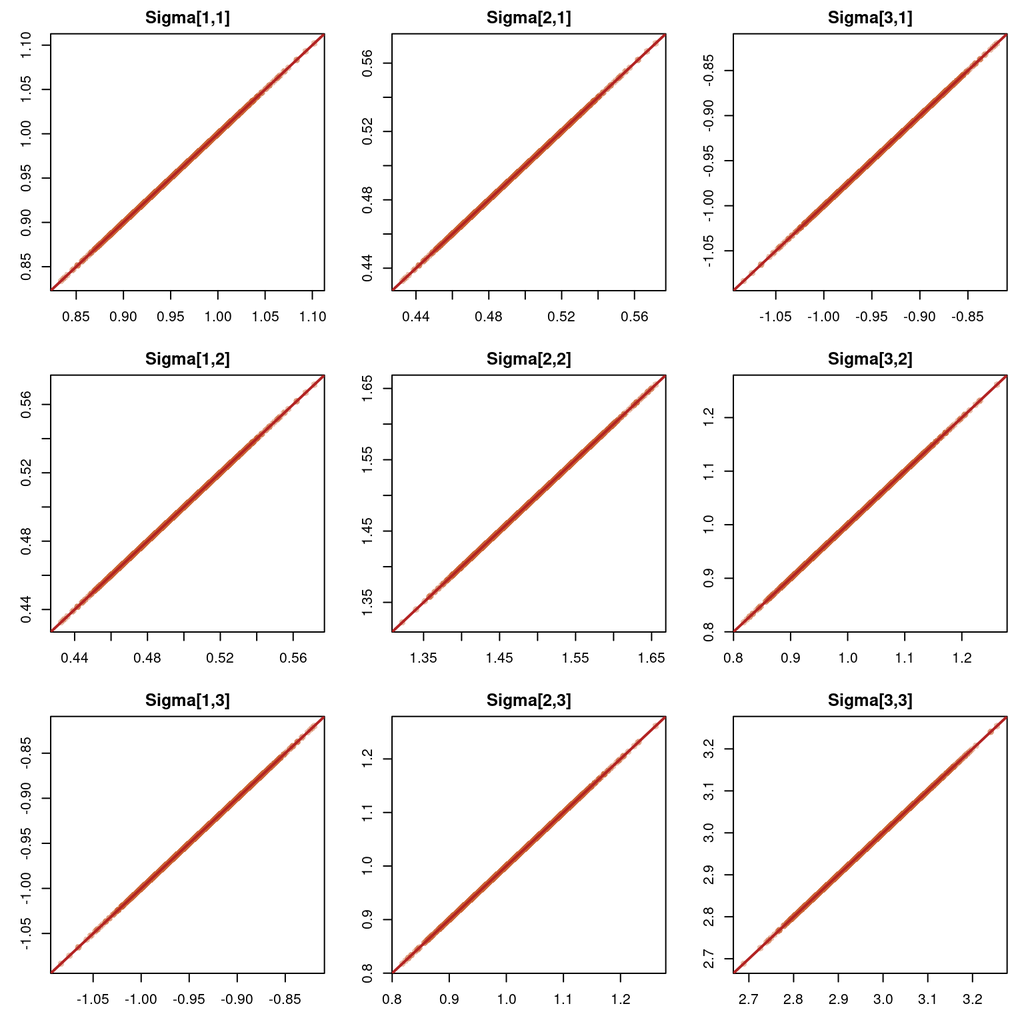

# 7 Empirical Analysis: C++ Accelerated Sampler (`mniwSamplerDivideAndConquer_rmniw`)

Redoing the streaming posterior analysis using `mniwSamplerDivideAndConquer_rmniw`, passing the row precision $\Omega = M^{-1}$ directly to `mniw::rmniw`.

```r
# 1. Streaming Divide & Conquer using C++ rmniw
set.seed(42)
res_dc_rmniw <- mniwSamplerDivideAndConquer_rmniw(data_blocks, m0, M0_inv, nu0, Psi0, n_samples = 2000)

# 2. Batch Full Data Analysis using C++ rmniw
set.seed(42)
res_batch_rmniw <- mniwSamplerDivideAndConquer_rmniw(full_data_block, m0, M0_inv, nu0, Psi0, n_samples = 2000)
```

## 7.1 Parameter Precision Comparison (`rmniw` Sampler)

```r
diff_m_rmniw     <- max(abs(res_dc_rmniw$post_params$m - res_batch_rmniw$post_params$m))
diff_M_inv_rmniw <- max(abs(res_dc_rmniw$post_params$M_inv - res_batch_rmniw$post_params$M_inv))
diff_Psi_rmniw   <- max(abs(res_dc_rmniw$post_params$Psi - res_batch_rmniw$post_params$Psi))
diff_nu_rmniw    <- abs(res_dc_rmniw$post_params$nu - res_batch_rmniw$post_params$nu)

param_comp_rmniw <- data.frame(
  Parameter_Matrix = c("Location Vector (m)", "Precision Matrix (M^{-1})", "Scale Matrix (Psi)", "Degrees of Freedom (nu)"),
  Max_Absolute_Difference = c(diff_m_rmniw, diff_M_inv_rmniw, diff_Psi_rmniw, diff_nu_rmniw)
)

kable(param_comp_rmniw, digits = 16, caption = "Numerical Equivalence of Posterior Parameters (rmniw)")
```

Numerical Equivalence of Posterior Parameters (rmniw)

| Parameter_Matrix | Max_Absolute_Difference |
| --- | --- |
| Location Vector (m) | 1.81900e-12 |
| Precision Matrix (M^{-1}) | 9.09500e-13 |
| Scale Matrix (Psi) | 1.81899e-11 |
| Degrees of Freedom (nu) | 0.00000e+00 |

## 7.2 Posterior Parameter Summaries (`rmniw` Sampler)

### 7.2.1 Regression Coefficients (Beta) Summary (rmniw Sampler)

| Param | Mean | SD | 2.5% | 97.5% |
| --- | --- | --- | --- | --- |
| Beta[1,1] | 0.0255 | 0.0281 | -0.0291 | 0.0773 |
| Beta[2,1] | 1.0068 | 0.0286 | 0.9517 | 1.0628 |
| Beta[3,1] | 4.0101 | 0.0200 | 3.9711 | 4.0493 |
| Beta[4,1] | 0.4904 | 0.0161 | 0.4587 | 0.5203 |
| Beta[1,2] | 0.0014 | 0.0359 | -0.0679 | 0.0708 |
| Beta[2,2] | 3.0046 | 0.0363 | 2.9329 | 3.0735 |
| Beta[3,2] | 1.4861 | 0.0243 | 1.4383 | 1.5336 |
| Beta[4,2] | 0.9974 | 0.0207 | 0.9562 | 1.0359 |
| Beta[1,3] | -0.0460 | 0.0499 | -0.1456 | 0.0545 |
| Beta[2,3] | 1.9941 | 0.0527 | 1.8885 | 2.0961 |
| Beta[3,3] | -1.0335 | 0.0355 | -1.1050 | -0.9653 |
| Beta[4,3] | 5.0075 | 0.0288 | 4.9520 | 5.0646 |

### 7.2.2 Covariance Matrix (Sigma) Summary (rmniw Sampler)

| Param | Mean | SD | 2.5% | 97.5% |
| --- | --- | --- | --- | --- |
| Sigma[1,1] | 0.9554 | 0.0385 | 0.8820 | 1.0335 |
| Sigma[2,1] | 0.4960 | 0.0374 | 0.4245 | 0.5693 |
| Sigma[3,1] | -0.9388 | 0.0552 | -1.0510 | -0.8331 |
| Sigma[1,2] | 0.4960 | 0.0374 | 0.4245 | 0.5693 |
| Sigma[2,2] | 1.4911 | 0.0599 | 1.3768 | 1.6154 |
| Sigma[3,2] | 1.0082 | 0.0675 | 0.8798 | 1.1439 |
| Sigma[1,3] | -0.9388 | 0.0552 | -1.0510 | -0.8331 |
| Sigma[2,3] | 1.0082 | 0.0675 | 0.8798 | 1.1439 |
| Sigma[3,3] | 2.9686 | 0.1218 | 2.7462 | 3.2197 |

## 7.3 Quantile-Quantile (QQ) Validation (`rmniw` Sampler)

### 7.3.1 Regression Coefficients ($\beta$) QQ-Plots (`rmniw` D&C vs. Batch)

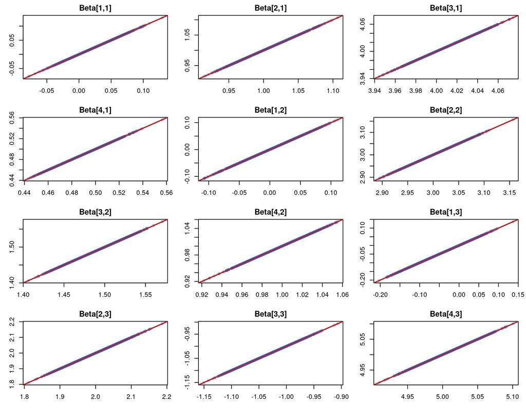

### 7.3.2 Covariance Matrix ($\Sigma$) QQ-Plots (`rmniw` D&C vs. Batch)

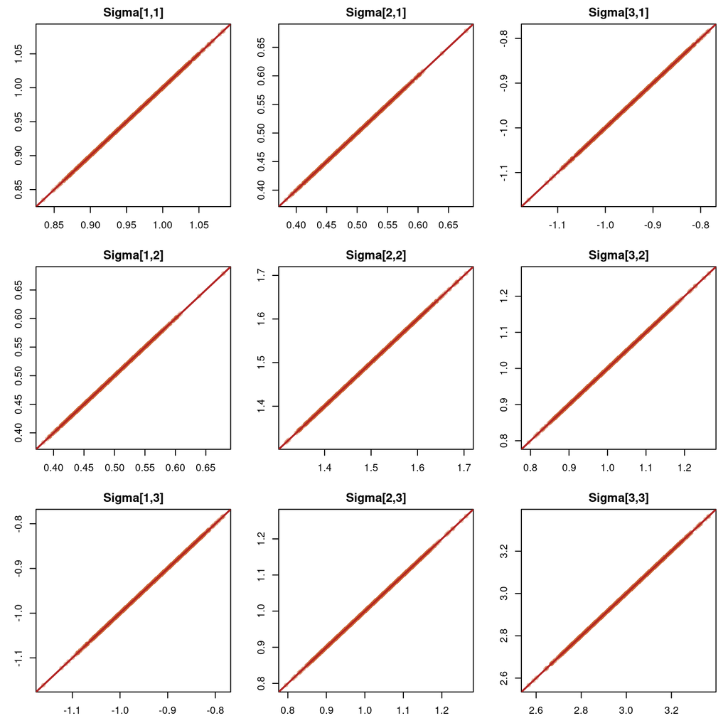

# 8 Execution Timing Benchmark

Comparing runtime between custom R composition sampling (`mniwSamplerDivideAndConquer`) and C++ accelerated sampling (`mniwSamplerDivideAndConquer_rmniw`) across 10,000 posterior draws.

```r
n_bench <- 10000

t_custom <- system.time({
  res_bench_custom <- mniwSamplerDivideAndConquer(data_blocks, m0, M0_inv, nu0, Psi0, n_samples = n_bench)
})["elapsed"]

t_rmniw <- system.time({
  res_bench_rmniw <- mniwSamplerDivideAndConquer_rmniw(data_blocks, m0, M0_inv, nu0, Psi0, n_samples = n_bench)
})["elapsed"]

timing_df <- data.frame(
  Sampler_Implementation = c("Custom R Sampler (mniwSamplerDivideAndConquer)",
                             "C++ Accelerated Sampler (mniwSamplerDivideAndConquer_rmniw)"),
  Elapsed_Time_Sec = c(as.numeric(t_custom), as.numeric(t_rmniw)),
  Speedup_Factor   = c(1.0, as.numeric(t_custom / t_rmniw))
)

kable(timing_df, digits = 4, caption = paste0("Sampling Execution Time Comparison (", n_bench, " Samples)"))
```

Sampling Execution Time Comparison (10000 Samples)

| Sampler_Implementation | Elapsed_Time_Sec | Speedup_Factor |
| --- | --- | --- |
| Custom R Sampler (mniwSamplerDivideAndConquer) | 0.503 | 1.0000 |
| C++ Accelerated Sampler (mniwSamplerDivideAndConquer_rmniw) | 0.021 | 23.9524 |

The C++ implementation in `mniw::rmniw` provides substantial execution speedup over pure R loops due to compiled C++ sampling routines and optimized matrix computations.